# Lab 2

# **Lab 2**

# **DATA SETUP (Step 0-2)**

**0. Import the data and declare your package dependencies.**

```python
# For the fallowing, I used the basic code that Kaggle gives plus a couple adjusted chatgpt had because I was orginally having issues loading it in and was
# unclear why


# Install dependencies as needed:
# pip install pandas
import numpy as np
import pandas as pd
import matplotlib.pyplot as plt

# Set the path to the file you'd like to load
# IMPORTANT: Replace '/content/avacado-updated-2022.csv' with the actual path to your file in Colab
file_path = "/avocado-updated-2020.csv"

# Load the data using pandas.read_csv
try:
  df = pd.read_csv(file_path)
  print("First 5 records:", df.head())
except FileNotFoundError:
  print(f"Error: File not found at {file_path}. Please make sure the file is uploaded and the path is correct.")
except Exception as e:
  print(f"An error occurred while reading the file: {e}")
```

```
First 5 records:          date  average_price  total_volume       4046       4225      4770  \
0  2015-01-04           1.22      40873.28    2819.50   28287.42     49.90
1  2015-01-04           1.79       1373.95      57.42     153.88      0.00
2  2015-01-04           1.00     435021.49  364302.39   23821.16     82.15
3  2015-01-04           1.76       3846.69    1500.15     938.35      0.00
4  2015-01-04           1.08     788025.06   53987.31  552906.04  39995.03

   total_bags  small_bags  large_bags  xlarge_bags          type  year  \
0     9716.46     9186.93      529.53          0.0  conventional  2015
1     1162.65     1162.65        0.00          0.0       organic  2015
2    46815.79    16707.15    30108.64          0.0  conventional  2015
3     1408.19     1071.35      336.84          0.0       organic  2015
4   141136.68   137146.07     3990.61          0.0  conventional  2015

              geography
0                Albany
1                Albany
2               Atlanta
3               Atlanta
4  Baltimore/Washington
```

**1. Briefly describe the data set. What information does it contain?**

```python
print("Rows, Cols:", df.shape)
print("\nColumns:", list(df.columns))
print("\nTypes:")
print(df.dtypes)

print("\nMissing values per column:")
print(df.isna().sum())

print("\nQuick numeric summary:")
display(df.describe(include='all').T)

df.head(10)
```

```
Rows, Cols: (33045, 13)

Columns: ['date', 'average_price', 'total_volume', '4046', '4225', '4770', 'total_bags', 'small_bags', 'large_bags', 'xlarge_bags', 'type', 'year', 'geography']

Types:
date              object
average_price    float64
total_volume     float64
4046             float64
4225             float64
4770             float64
total_bags       float64
small_bags       float64
large_bags       float64
xlarge_bags      float64
type              object
year               int64
geography         object
dtype: object

Missing values per column:
date             0
average_price    0
total_volume     0
4046             0
4225             0
4770             0
total_bags       0
small_bags       0
large_bags       0
xlarge_bags      0
type             0
year             0
geography        0
dtype: int64

Quick numeric summary:
```

|  | count | unique | top | freq | mean | std | min | 25% | 50% | 75% | max |
| --- | --- | --- | --- | --- | --- | --- | --- | --- | --- | --- | --- |
| date | 33045 | 306 | 2020-11-29 | 108 | NaN | NaN | NaN | NaN | NaN | NaN | NaN |
| average_price | 33045.0 | NaN | NaN | NaN | 1.379941 | 0.378972 | 0.44 | 1.1 | 1.35 | 1.62 | 3.25 |
| total_volume | 33045.0 | NaN | NaN | NaN | 968399.676291 | 3934532.637117 | 84.56 | 15118.95 | 129116.98 | 505828.46 | 63716144.15 |
| 4046 | 33045.0 | NaN | NaN | NaN | 302391.405241 | 1301025.920091 | 0.0 | 767.31 | 10994.77 | 119021.85 | 22743616.17 |
| 4225 | 33045.0 | NaN | NaN | NaN | 279769.300885 | 1151052.266745 | 0.0 | 2712.47 | 23436.0 | 135238.94 | 20470572.61 |
| 4770 | 33045.0 | NaN | NaN | NaN | 21482.550773 | 100160.701957 | 0.0 | 0.0 | 178.09 | 5096.53 | 2546439.11 |
| total_bags | 33045.0 | NaN | NaN | NaN | 364673.476366 | 1564003.996535 | 0.0 | 9121.86 | 53222.24 | 174431.43 | 31689188.6 |
| small_bags | 33045.0 | NaN | NaN | NaN | 250198.016346 | 1037734.175672 | 0.0 | 6478.63 | 36876.99 | 120662.4 | 20550406.59 |
| large_bags | 33045.0 | NaN | NaN | NaN | 106732.875171 | 516722.594117 | 0.0 | 466.29 | 6375.86 | 40417.23 | 13327600.76 |
| xlarge_bags | 33045.0 | NaN | NaN | NaN | 7742.584637 | 48198.030842 | 0.0 | 0.0 | 0.0 | 804.44 | 1403184.04 |
| type | 33045 | 2 | conventional | 16524 | NaN | NaN | NaN | NaN | NaN | NaN | NaN |
| year | 33045.0 | NaN | NaN | NaN | 2017.460887 | 1.699747 | 2015.0 | 2016.0 | 2017.0 | 2019.0 | 2020.0 |
| geography | 33045 | 54 | Albany | 612 | NaN | NaN | NaN | NaN | NaN | NaN | NaN |

|  | date | average_price | total_volume | 4046 | 4225 | 4770 | total_bags | small_bags | large_bags | xlarge_bags | type | year | geography |
| --- | --- | --- | --- | --- | --- | --- | --- | --- | --- | --- | --- | --- | --- |
| 0 | 2015-01-04 | 1.22 | 40873.28 | 2819.50 | 28287.42 | 49.90 | 9716.46 | 9186.93 | 529.53 | 0.0 | conventional | 2015 | Albany |
| 1 | 2015-01-04 | 1.79 | 1373.95 | 57.42 | 153.88 | 0.00 | 1162.65 | 1162.65 | 0.00 | 0.0 | organic | 2015 | Albany |
| 2 | 2015-01-04 | 1.00 | 435021.49 | 364302.39 | 23821.16 | 82.15 | 46815.79 | 16707.15 | 30108.64 | 0.0 | conventional | 2015 | Atlanta |
| 3 | 2015-01-04 | 1.76 | 3846.69 | 1500.15 | 938.35 | 0.00 | 1408.19 | 1071.35 | 336.84 | 0.0 | organic | 2015 | Atlanta |
| 4 | 2015-01-04 | 1.08 | 788025.06 | 53987.31 | 552906.04 | 39995.03 | 141136.68 | 137146.07 | 3990.61 | 0.0 | conventional | 2015 | Baltimore/Washington |
| 5 | 2015-01-04 | 1.29 | 19137.28 | 8040.64 | 6557.47 | 657.48 | 3881.69 | 3881.69 | 0.00 | 0.0 | organic | 2015 | Baltimore/Washington |
| 6 | 2015-01-04 | 1.01 | 80034.32 | 44562.12 | 24964.23 | 2752.35 | 7755.62 | 6064.30 | 1691.32 | 0.0 | conventional | 2015 | Boise |
| 7 | 2015-01-04 | 1.64 | 1505.12 | 1.27 | 1129.50 | 0.00 | 374.35 | 186.67 | 187.68 | 0.0 | organic | 2015 | Boise |
| 8 | 2015-01-04 | 1.02 | 491738.00 | 7193.87 | 396752.18 | 128.82 | 87663.13 | 87406.84 | 256.29 | 0.0 | conventional | 2015 | Boston |
| 9 | 2015-01-04 | 1.83 | 2192.13 | 8.66 | 939.43 | 0.00 | 1244.04 | 1244.04 | 0.00 | 0.0 | organic | 2015 | Boston |

Based on the description on the home page of the Kaggle dataset, it includes data on date, Average Price, Type (Conventional or organic), the year, the region (changed to geography in the new dataset we are using), Total volume, 4046 meanin the number of avacoados with Product lookup code 4046 sold, 4225 (same as before but PLU 4225), and 4770 (same as before put PLU 4470). Based on the printed dataset, other variables are included but those seem much more intuitive.

I also got some basic summary data, and a glipse of the data through the code lines

print(“numeric summary:”)

display(df.describe(include=‘all’).T)

df.head(10)

Nothing huge stands out yet, but some intresting basic information is displayed .

**2. Clean the data in any way you see fit.**

```python
!pip install us
```

```
Downloading us-3.2.0-py3-none-any.whl (13 kB)

Downloading jellyfish-1.2.0-cp312-cp312-manylinux_2_17_x86_64.manylinux2014_x86_64.whl (355 kB)

   ━━━━━━━━━━━━━━━━━━━━━━━━━━━━━━━━━━━━━━━━ 355.9/355.9 kB 5.9 MB/s eta 0:00:00
```

```python
# I think one way I could clean it for easier data readability would be to get rid of spaces and replace them with _
df.columns = df.columns.str.strip().str.lower().str.replace(" ", "_")

#Another way, per the tips suggestion, is renaming the codes to what they mean -- had to search them up for this
df = df.rename(columns={
    "4046": "small_hass",
    "4225": "large_hass",
    "4770": "xlarge_hass"
})

# The main thing I need to clean is the who geography issue -- so I could find each unique value, then sort them into US, Region, State, or Metro based on where they fit into the data
import pandas as pd

# get all unique values
geo_vals = df["geography"].unique()

# Define known categories and what they could be named as
us_labels = {"total u.s.", "totalus", "total_us", "total u.s", "totalu.s."} # Added "totalu.s." and "total_u.s." for consistent matching after removing spaces
major_regions = {
    "west", "northeast", "southeast", "southcentral",
    "midsouth", "greatlakes", "plains", "westtex/newmexico"
}

# list of U.S. states for matching (lowercase) -- this I searched up because I didn't want to mannually put in each state one by one
from us import states
state_names = set([s.name.lower() for s in states.STATES])  # uses 'us' package

# Define classification logic
def classify_geo(name):
    n = str(name).strip().lower().replace(" ", "") # Remove spaces for consistent matching
    if n in us_labels:
        return "US"
    elif n in major_regions:
        return "Region"
    elif n in state_names:
        return "State"
    else:
        return "Metro"

df["geo_level"] = df["geography"].apply(classify_geo)

# The rest of this I used chaptgpt support to see how to check to make sure I did it correctly, because I went through the rest of the lab and was off on somethings
#before
print("Value counts for geo_level:")
print(df["geo_level"].value_counts())

print("\nUnique geography names classified as US:")
print(df[df["geo_level"] == "US"]["geography"].unique())

# Print unique geography names that, after processing, match major_regions
print("\nUnique geography names that match major_regions after processing:")
processed_geo_names = df["geography"].apply(lambda x: str(x).strip().lower().replace(" ", ""))
matching_region_names = df["geography"][processed_geo_names.isin(major_regions)].unique()
print(matching_region_names)
```

```
Value counts for geo_level:
geo_level
Metro     26928
Region     4893
State       612
US          612
Name: count, dtype: int64

Unique geography names classified as US:
['Total U.S.']

Unique geography names that match major_regions after processing:
['Great Lakes' 'Midsouth' 'Northeast' 'Plains' 'South Central' 'Southeast'
 'West' 'West Tex/New Mexico']
```

Shows the amount of each, and when I did command F on the excel file it matched up correctly for at least Total US since that was the easiest to check

```python
df.head(10)
```

|  | date | average_price | total_volume | small_hass | large_hass | xlarge_hass | total_bags | small_bags | large_bags | xlarge_bags | type | year | geography | geo_level |
| --- | --- | --- | --- | --- | --- | --- | --- | --- | --- | --- | --- | --- | --- | --- |
| 0 | 2015-01-04 | 1.22 | 40873.28 | 2819.50 | 28287.42 | 49.90 | 9716.46 | 9186.93 | 529.53 | 0.0 | conventional | 2015 | Albany | Metro |
| 1 | 2015-01-04 | 1.79 | 1373.95 | 57.42 | 153.88 | 0.00 | 1162.65 | 1162.65 | 0.00 | 0.0 | organic | 2015 | Albany | Metro |
| 2 | 2015-01-04 | 1.00 | 435021.49 | 364302.39 | 23821.16 | 82.15 | 46815.79 | 16707.15 | 30108.64 | 0.0 | conventional | 2015 | Atlanta | Metro |
| 3 | 2015-01-04 | 1.76 | 3846.69 | 1500.15 | 938.35 | 0.00 | 1408.19 | 1071.35 | 336.84 | 0.0 | organic | 2015 | Atlanta | Metro |
| 4 | 2015-01-04 | 1.08 | 788025.06 | 53987.31 | 552906.04 | 39995.03 | 141136.68 | 137146.07 | 3990.61 | 0.0 | conventional | 2015 | Baltimore/Washington | Metro |
| 5 | 2015-01-04 | 1.29 | 19137.28 | 8040.64 | 6557.47 | 657.48 | 3881.69 | 3881.69 | 0.00 | 0.0 | organic | 2015 | Baltimore/Washington | Metro |
| 6 | 2015-01-04 | 1.01 | 80034.32 | 44562.12 | 24964.23 | 2752.35 | 7755.62 | 6064.30 | 1691.32 | 0.0 | conventional | 2015 | Boise | Metro |
| 7 | 2015-01-04 | 1.64 | 1505.12 | 1.27 | 1129.50 | 0.00 | 374.35 | 186.67 | 187.68 | 0.0 | organic | 2015 | Boise | Metro |
| 8 | 2015-01-04 | 1.02 | 491738.00 | 7193.87 | 396752.18 | 128.82 | 87663.13 | 87406.84 | 256.29 | 0.0 | conventional | 2015 | Boston | Metro |
| 9 | 2015-01-04 | 1.83 | 2192.13 | 8.66 | 939.43 | 0.00 | 1244.04 | 1244.04 | 0.00 | 0.0 | organic | 2015 | Boston | Metro |

So now we still have the orignal geography variable showing us the place, but the new variable I made geo_level shoudl help us sort it quicker

# **EXERCISES (steps 3-5)**

**3. Which major geographical region sold the most total organic, small Hass avocados in 2017?**

```python
# Filtering the data for the specifications that I want
region_2017 = (
    df[
        (df["geo_level"] == "Region") &
        (df["type"].str.lower() == "organic") &
        (df["year"] == 2017)
    ]
    .groupby("geography", as_index=False)["small_hass"]
    .sum()
    .sort_values("small_hass", ascending=False)
)

region_2017
```

|  | geography | small_hass |
| --- | --- | --- |
| 6 | West | 1870206.29 |
| 4 | South Central | 1717104.19 |
| 2 | Northeast | 925832.36 |
| 5 | Southeast | 285124.34 |
| 0 | Great Lakes | 202487.68 |
| 1 | Midsouth | 186395.50 |
| 3 | Plains | 168583.40 |
| 7 | West Tex/New Mexico | 110910.95 |

It looks like the West region sold the most total organic, small Hass avacado’s in 2017, which from my bias perspective makes sense as I feel like there is a sterotype around how much west coast people love avacodo’s

**4. Split the date variable into month, day, and year variables. In which month is the highest average volume of avocado sales**

```python
# Ensure the date column is a datetime
df["date"] = pd.to_datetime(df["date"])

# If month/day/year columns aren’t already there, create them
df["year"] = df["date"].dt.year
df["month"] = df["date"].dt.month
df["day"] = df["date"].dt.day

# Group by month and compute average total volume
monthly_avg = (
    df.groupby("month", as_index=False)["total_volume"]
    .mean()
    .sort_values("total_volume", ascending=False)
)

pd.options.display.float_format = '{:.2f}'.format # I searched this command up because it kept coming up as scientific notation
display(monthly_avg)
```

|  | month | total_volume |
| --- | --- | --- |
| 4 | 5 | 1123632.25 |
| 1 | 2 | 1095373.83 |
| 5 | 6 | 1051246.57 |
| 3 | 4 | 1016581.69 |
| 2 | 3 | 995715.04 |
| 0 | 1 | 985312.16 |
| 6 | 7 | 983268.10 |
| 7 | 8 | 949924.93 |
| 8 | 9 | 906477.26 |
| 9 | 10 | 844686.29 |
| 10 | 11 | 822347.02 |
| 11 | 12 | 807669.47 |

**5. Which metro area geographical regions sold the most total avocados? Plot side-by-side box-plots of the total volume for only the five metro geographical regions with the highest averages for the total_volume variable.**

```python
import matplotlib.pyplot as plt

# Filter to only metro areas
df_metro = df[df["geo_level"] == "Metro"]

# Compute average total volume per metro area
metro_avg = (
    df_metro.groupby("geography", as_index=False)["total_volume"]
    .mean()
    .sort_values("total_volume", ascending=False)
)

# Display the top 5 metros
top5 = metro_avg.head(5)
top5
```

|  | geography | total_volume |
| --- | --- | --- |
| 20 | Los Angeles | 1567566.16 |
| 25 | New York | 863145.82 |
| 10 | Dallas/Ft. Worth | 712751.90 |
| 16 | Houston | 687653.34 |
| 29 | Phoenix/Tucson | 625038.26 |

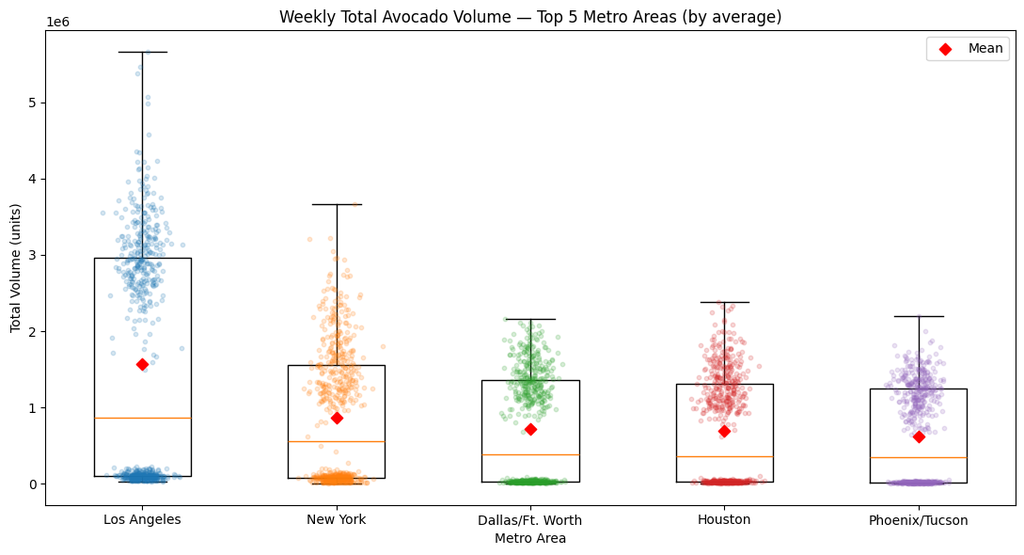

```python
import matplotlib.pyplot as plt
import numpy as np
import pandas as pd
import seaborn as sns

# Filter to only metro areas (re-calculated as this cell was executed independently)
df_metro = df[df["geo_level"] == "Metro"].copy()

# Compute average total volume per metro area and get the top 5 (re-calculated)
metro_avg = (
    df_metro.groupby("geography", as_index=False)["total_volume"]
    .mean()
    .nlargest(5, "total_volume")
)

# Keep only the rows belonging to the top 5 metro regions (re-calculated)
top5_names = metro_avg["geography"].tolist()
df_top5 = df_metro[df_metro["geography"].isin(top5_names)].copy()

# Sort by mean volume so plots appear in descending order - set geography as categorical (re-calculated)
df_top5["geography"] = pd.Categorical(df_top5["geography"], categories=top5_names, ordered=True)
mean_order = top5_names # mean_order should be the list of top 5 names in correct order

# 5) make side-by-side boxplots; overlay every observation + the mean
plt.figure(figsize=(11,6))

# boxplots (one per metro)
plt.boxplot(
    [df_top5.loc[df_top5["geography"] == g, "total_volume"] for g in mean_order],
    labels=mean_order,
    patch_artist=False
)

# every observation (slight jitter so points don't stack)
for i, g in enumerate(mean_order, start=1):
    y = df_top5.loc[df_top5["geography"] == g, "total_volume"].values
    x = np.random.normal(loc=i, scale=0.06, size=len(y))
    plt.scatter(x, y, s=10, alpha=0.18, zorder=2)

# overlay the mean as a diamond marker
means = [df_top5.loc[df_top5["geography"] == g, "total_volume"].mean() for g in mean_order]
plt.scatter(range(1, 6), means, marker="D", s=40, zorder=3, color="red", label="Mean")

plt.title("Weekly Total Avocado Volume — Top 5 Metro Areas (by average)")
plt.xlabel("Metro Area")
plt.ylabel("Total Volume (units)")
plt.legend()
plt.tight_layout()
plt.show()
```

As we can see, LA, NY< Sallas/FT.Worth, Houston, and Phoenix/Tucson sold the most total avacoado’s, in that order

# **Pivoting**

The following four California geographical regions are in this data set: “Los Angeles”, “San Diego”, “Sacramento”, and “San Francisco”.

**6. From your cleaned data set, create a data set with only these California regions and answer the following questions about these California regions only.**

```python
# Create a list of the California regions to filter by
california_regions = ["Los Angeles", "San Diego", "Sacramento", "San Francisco"]

# Filter the main DataFrame to create a new DataFrame with only California regions
df_california = df[df["geography"].isin(california_regions)].copy()

# Display the first few rows of the new California DataFrame
print("First 5 records of the California DataFrame:")
display(df_california.head())

print("\nUnique geographies in the California DataFrame:")
print(df_california["geography"].unique())
```

```
First 5 records of the California DataFrame:
```

|  | date | average_price | total_volume | small_hass | large_hass | xlarge_hass | total_bags | small_bags | large_bags | xlarge_bags | type | year | geography | geo_level | month | day |
| --- | --- | --- | --- | --- | --- | --- | --- | --- | --- | --- | --- | --- | --- | --- | --- | --- |
| 44 | 2015-01-04 | 0.85 | 2682159.95 | 1837999.65 | 524430.47 | 64225.78 | 255504.05 | 215571.80 | 36981.72 | 2950.53 | conventional | 2015 | Los Angeles | Metro | 1 | 4 |
| 45 | 2015-01-04 | 1.25 | 54495.54 | 47721.51 | 1723.40 | 0.00 | 5050.63 | 5050.63 | 0.00 | 0.00 | organic | 2015 | Los Angeles | Metro | 1 | 4 |
| 80 | 2015-01-04 | 1.05 | 430138.88 | 110693.69 | 270107.61 | 9737.50 | 39600.08 | 39600.08 | 0.00 | 0.00 | conventional | 2015 | Sacramento | Metro | 1 | 4 |
| 81 | 2015-01-04 | 1.33 | 9213.49 | 3727.52 | 4327.52 | 0.00 | 1158.45 | 1158.45 | 0.00 | 0.00 | organic | 2015 | Sacramento | Metro | 1 | 4 |
| 82 | 2015-01-04 | 0.94 | 461607.33 | 244152.26 | 165299.33 | 15302.75 | 36852.99 | 30884.29 | 5595.00 | 373.70 | conventional | 2015 | San Diego | Metro | 1 | 4 |

```
Unique geographies in the California DataFrame:
['Los Angeles' 'Sacramento' 'San Diego' 'San Francisco']
```

**7. In which California regions is the price of organic versus conventional avocados most different? Support your answer with a few summary statistics AND a visualization.**

```python
california_avg_price = df_california.groupby(["geography", "type"])["average_price"].mean().reset_index()
display(california_avg_price)
```

|  | geography | type | average_price |
| --- | --- | --- | --- |
| 0 | Los Angeles | conventional | 1.05 |
| 1 | Los Angeles | organic | 1.57 |
| 2 | Sacramento | conventional | 1.30 |
| 3 | Sacramento | organic | 1.87 |
| 4 | San Diego | conventional | 1.11 |
| 5 | San Diego | organic | 1.80 |
| 6 | San Francisco | conventional | 1.40 |
| 7 | San Francisco | organic | 2.12 |

```python
california_pivot = california_avg_price.pivot(index='geography', columns='type', values='average_price')
california_pivot['price_difference'] = abs(california_pivot['organic'] - california_pivot['conventional'])
display(california_pivot)
```

| type geography | conventional | organic | price_difference |
| --- | --- | --- | --- |
| Los Angeles | 1.05 | 1.57 | 0.53 |
| Sacramento | 1.30 | 1.87 | 0.58 |
| San Diego | 1.11 | 1.80 | 0.68 |
| San Francisco | 1.40 | 2.12 | 0.72 |

As we can see by these summary statistics, the biggest price difference between conventional and organic is San Francisco with a difference of 72 cents

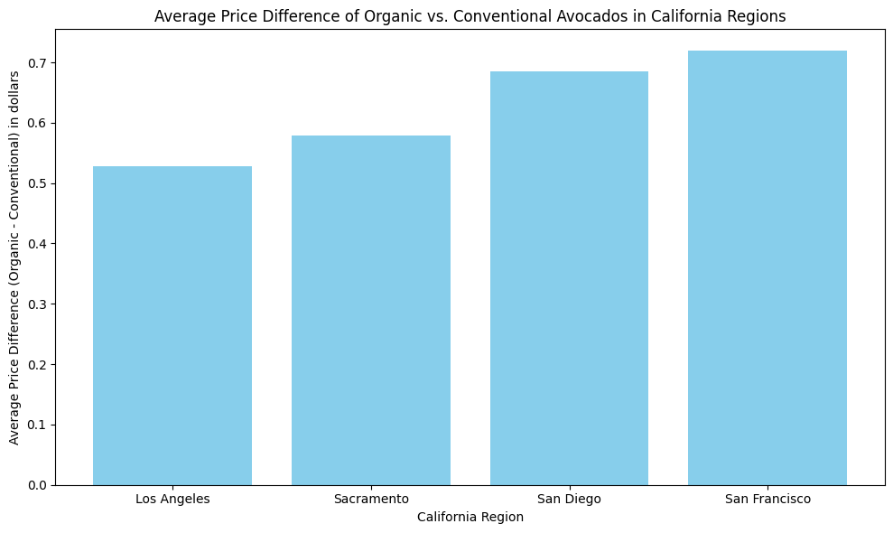

```python
plt.figure(figsize=(10, 6))
plt.bar(california_pivot.index, california_pivot['price_difference'], color='skyblue')
plt.xlabel("California Region")
plt.ylabel("Average Price Difference (Organic - Conventional) in dollars")
plt.title("Average Price Difference of Organic vs. Conventional Avocados in California Regions")
plt.tight_layout()
plt.show()
```

This is also backed by the results of this graph with San Francisco being the highest

**8. The following plot shows, for all four California regions, the proportion of the average Hass avocado sales that are small, large, or extra large; conventional vs. organic. Recreate the plot; you do not have to replicate the exact finishing touches - e.g., color, theme - but your plot should resemble the content of this plot.**

```python
california_sales = df_california.groupby(["geography", "type"])[["small_hass", "large_hass", "xlarge_hass"]].sum().reset_index()
california_sales['total_hass_volume'] = california_sales['small_hass'] + california_sales['large_hass'] + california_sales['xlarge_hass']
display(california_sales)
```

|  | geography | type | small_hass | large_hass | xlarge_hass | total_hass_volume |
| --- | --- | --- | --- | --- | --- | --- |
| 0 | Los Angeles | conventional | 358923415.42 | 135815746.42 | 29704534.92 | 524443696.76 |
| 1 | Los Angeles | organic | 4419271.78 | 6366091.52 | 1846.80 | 10787210.10 |
| 2 | Sacramento | conventional | 43232633.24 | 74359551.47 | 1937983.58 | 119530168.29 |
| 3 | Sacramento | organic | 859521.15 | 1310504.12 | 236.44 | 2170261.71 |
| 4 | San Diego | conventional | 50120593.58 | 42872467.04 | 5496844.31 | 98489904.93 |
| 5 | San Diego | organic | 787358.89 | 2225778.08 | 405.02 | 3013541.99 |
| 6 | San Francisco | conventional | 66046965.07 | 137509490.63 | 4569070.59 | 208125526.29 |
| 7 | San Francisco | organic | 2540730.48 | 3473130.01 | 660.76 | 6014521.25 |

```python
california_sales['small_hass_proportion'] = california_sales['small_hass'] / california_sales['total_hass_volume']
california_sales['large_hass_proportion'] = california_sales['large_hass'] / california_sales['total_hass_volume']
california_sales['xlarge_hass_proportion'] = california_sales['xlarge_hass'] / california_sales['total_hass_volume']
display(california_sales)
```

|  | geography | type | small_hass | large_hass | xlarge_hass | total_hass_volume | small_hass_proportion | large_hass_proportion | xlarge_hass_proportion |
| --- | --- | --- | --- | --- | --- | --- | --- | --- | --- |
| 0 | Los Angeles | conventional | 358923415.42 | 135815746.42 | 29704534.92 | 524443696.76 | 0.68 | 0.26 | 0.06 |
| 1 | Los Angeles | organic | 4419271.78 | 6366091.52 | 1846.80 | 10787210.10 | 0.41 | 0.59 | 0.00 |
| 2 | Sacramento | conventional | 43232633.24 | 74359551.47 | 1937983.58 | 119530168.29 | 0.36 | 0.62 | 0.02 |
| 3 | Sacramento | organic | 859521.15 | 1310504.12 | 236.44 | 2170261.71 | 0.40 | 0.60 | 0.00 |
| 4 | San Diego | conventional | 50120593.58 | 42872467.04 | 5496844.31 | 98489904.93 | 0.51 | 0.44 | 0.06 |
| 5 | San Diego | organic | 787358.89 | 2225778.08 | 405.02 | 3013541.99 | 0.26 | 0.74 | 0.00 |
| 6 | San Francisco | conventional | 66046965.07 | 137509490.63 | 4569070.59 | 208125526.29 | 0.32 | 0.66 | 0.02 |
| 7 | San Francisco | organic | 2540730.48 | 3473130.01 | 660.76 | 6014521.25 | 0.42 | 0.58 | 0.00 |

```python
california_proportions_melted = california_sales.melt(
    id_vars=['geography', 'type'],
    value_vars=['small_hass_proportion', 'large_hass_proportion', 'xlarge_hass_proportion'],
    var_name='hass_size',
    value_name='proportion'
)
display(california_proportions_melted)
```

|  | geography | type | hass_size | proportion |
| --- | --- | --- | --- | --- |
| 0 | Los Angeles | conventional | small_hass_proportion | 0.68 |
| 1 | Los Angeles | organic | small_hass_proportion | 0.41 |
| 2 | Sacramento | conventional | small_hass_proportion | 0.36 |
| 3 | Sacramento | organic | small_hass_proportion | 0.40 |
| 4 | San Diego | conventional | small_hass_proportion | 0.51 |
| 5 | San Diego | organic | small_hass_proportion | 0.26 |
| 6 | San Francisco | conventional | small_hass_proportion | 0.32 |
| 7 | San Francisco | organic | small_hass_proportion | 0.42 |
| 8 | Los Angeles | conventional | large_hass_proportion | 0.26 |
| 9 | Los Angeles | organic | large_hass_proportion | 0.59 |
| 10 | Sacramento | conventional | large_hass_proportion | 0.62 |
| 11 | Sacramento | organic | large_hass_proportion | 0.60 |
| 12 | San Diego | conventional | large_hass_proportion | 0.44 |
| 13 | San Diego | organic | large_hass_proportion | 0.74 |
| 14 | San Francisco | conventional | large_hass_proportion | 0.66 |
| 15 | San Francisco | organic | large_hass_proportion | 0.58 |
| 16 | Los Angeles | conventional | xlarge_hass_proportion | 0.06 |
| 17 | Los Angeles | organic | xlarge_hass_proportion | 0.00 |
| 18 | Sacramento | conventional | xlarge_hass_proportion | 0.02 |
| 19 | Sacramento | organic | xlarge_hass_proportion | 0.00 |
| 20 | San Diego | conventional | xlarge_hass_proportion | 0.06 |
| 21 | San Diego | organic | xlarge_hass_proportion | 0.00 |
| 22 | San Francisco | conventional | xlarge_hass_proportion | 0.02 |
| 23 | San Francisco | organic | xlarge_hass_proportion | 0.00 |

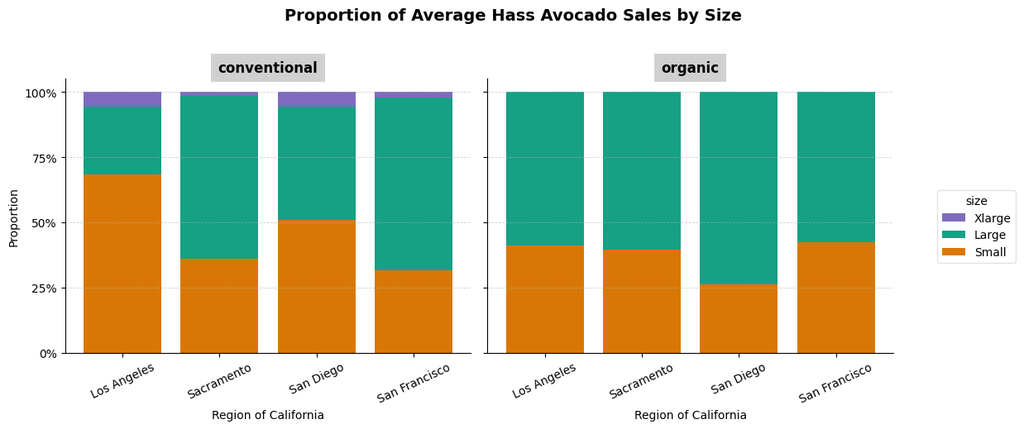

```python
import numpy as np
import pandas as pd
import matplotlib.pyplot as plt
from matplotlib.ticker import PercentFormatter
from matplotlib.patches import Patch # Import Patch for creating legend handles

# Create a copy of the melted proportions data
tbl = california_proportions_melted.copy()

# Define the desired order and labels for geographies, types, and sizes
geo_order  = ["Los Angeles", "Sacramento", "San Diego", "San Francisco"]
type_order = ["conventional", "organic"]
size_order = ["small_hass_proportion", "large_hass_proportion", "xlarge_hass_proportion"]
size_label = {"small_hass_proportion":"Small",
              "large_hass_proportion":"Large",
              "xlarge_hass_proportion":"Xlarge"}

# Filter the data to include only the specified California regions and types
tbl = tbl[tbl["geography"].isin(geo_order)].copy() #
tbl["geography"] = pd.Categorical(tbl["geography"], categories=geo_order, ordered=True)
tbl["type"] = tbl["type"].str.lower()
tbl = tbl[tbl["type"].isin(type_order)].copy() # Use .copy()
tbl["type"] = pd.Categorical(tbl["type"], categories=type_order, ordered=True)
tbl["hass_size"] = pd.Categorical(tbl["hass_size"], categories=size_order, ordered=True)

# DColors for each -- searched up on chat what codes would be close to the colors I wanted
color_for = {"Small":"#D97706", "Large":"#16A085", "Xlarge":"#7E6BBF"}

# Create a figure and a set of subplots (1 row, 2 columns), sharey=True ensures both subplots share the same y-axis
fig, axes = plt.subplots(1, 2, figsize=(12.5, 5), sharey=True)

# Loop through each avocado type (conventional and organic) to create a subplot
for ax, t in zip(axes, type_order):
    # Filter the data for the current type
    sub = tbl[tbl["type"] == t].copy() # Use .copy()

    # Pivot the data to a wide format suitable for stacking, index='geography' makes geography the rows, columns='hass_size' makes hass_size the columns, values='proportion' fills the table with proportion values
    # .reindex(geo_order) ensures the geographies are in the desired order
    p = sub.pivot(index="geography", columns="hass_size", values="proportion").reindex(geo_order)

    # Ensure all size columns exist in the pivoted data (fill with 0.0 if not present)
    for col in size_order:
        if col not in p.columns:
            p[col] = 0.0
    # Reindex columns to ensure they are in the desired size order for stacking
    p = p[size_order]

    # Create an array for the x-axis positions of the bars
    x = np.arange(len(p))
    # Initialize the 'bottom' of the stacked bars to zero
    bottom = np.zeros(len(p))

    # Loop through each size to create stacked bars
    for col in size_order:
        # Get the label and values for the current size
        lab = size_label[col]
        vals = p[col].to_numpy()
        # Add the bar for the current size on top of the previous sizes
        ax.bar(x, vals, bottom=bottom, label=lab, color=color_for[lab])
        # Update the 'bottom' for the next size
        bottom += vals

    # Add a title for the subplot (conventional or organic) with styling
    ax.set_title(t, bbox=dict(facecolor="#D0D0D0", edgecolor="none", pad=6), fontsize=12, weight="bold")

    # Set the x-axis ticks and labels
    ax.set_xticks(x)
    ax.set_xticklabels(p.index, rotation=25) # Rotate labels
    # Set the y-axis limits
    ax.set_ylim(0, 1.05)
    # Set the y-axis ticks
    ax.set_yticks([0, .25, .5, .75, 1.0])
    # Format the y-axis labels as percentages
    ax.yaxis.set_major_formatter(PercentFormatter(1.0))
    # Add a horizontal grid for better readability
    ax.grid(axis="y", linestyle="--", linewidth=0.6, alpha=0.6)
    # Hide the top and right spines (borders) of the plot
    for spine in ["top","right"]:
        ax.spines[spine].set_visible(False)
    # Set the y-axis label only for the left subplot
    if ax is axes[0]:
        ax.set_ylabel("Proportion")
    # Set the x-axis label for both subplots
    ax.set_xlabel("Region of California")

# Create custom legend handles
legend_handles = [
    Patch(facecolor=color_for["Xlarge"], label="Xlarge"),
    Patch(facecolor=color_for["Large"],  label="Large"),
    Patch(facecolor=color_for["Small"],  label="Small"),
]


fig.legend(
    legend_handles, ["Xlarge","Large","Small"], title="size",
    loc="center left", bbox_to_anchor=(0.905, 0.5), frameon=True,
    fancybox=True, edgecolor="#DDDDDD"
)

# Add a main title for the entire figure
fig.suptitle("Proportion of Average Hass Avocado Sales by Size", y=1.03, fontsize=14, weight="bold")
# Adjust the layout to prevent titles/labels from overlapping, leaving space for the legend
plt.tight_layout(rect=[0, 0, 0.88, 1])
# Display the plot
plt.show()
```

**Using Outside Data**

**A joke in the media is that Millennials can’t afford houses, because they spend all their money buying avocado toast. Let’s use this data set to address that claim.**

**Find or assemble a data set of real data, with house prices for these four California regions. Join this data set with your California avocado data set.**

**Use your new joined data set to make an argument about the relationship between house prices and avocado prices/sales.**

**Support your argument with a plot.**

I was able to find a datasource on redfin.com where I was able to import Data on LA, SAC, SD, and SF for each month/year, and the median house price… this was super nice because it let me filter on the website through what I wanted before importing it… here is me addressing the fallowing steps now

```python
!pip install openpyxl
```

```python
file_path = "/Cali_houseprice_data.xlsx" # Changed back to .xlsx

# Load the data using pandas.read_excel
try:
  df_house = pd.read_excel(file_path) # Changed to read_excel
  print("First 5 records:", df_house.head())

  # Fill forward the missing values in the 'Region' column based on how the excel was loaded in
  df_house['Region'] = df_house['Region'].ffill()

  print("\nFirst 5 records after filling missing regions:")
  display(df_house.head())

except FileNotFoundError:
  print(f"Error: File not found at {file_path}. Please make sure the file is uploaded and the path is correct.")
except Exception as e:
  print(f"An error occurred while reading the file: {e}")
```

```
First 5 records:                        Region Month of Period End  Median Sale Price
0  Los Angeles, CA metro area        January 2012          290000.00
1                         NaN       February 2012          300000.00
2                         NaN          March 2012          310000.00
3                         NaN          April 2012          315000.00
4                         NaN            May 2012          320000.00

First 5 records after filling missing regions:
```

|  | Region | Month of Period End | Median Sale Price |
| --- | --- | --- | --- |
| 0 | Los Angeles, CA metro area | January 2012 | 290000.00 |
| 1 | Los Angeles, CA metro area | February 2012 | 300000.00 |
| 2 | Los Angeles, CA metro area | March 2012 | 310000.00 |
| 3 | Los Angeles, CA metro area | April 2012 | 315000.00 |
| 4 | Los Angeles, CA metro area | May 2012 | 320000.00 |

```python
df_house
```

|  | Region | Month of Period End | Median Sale Price |
| --- | --- | --- | --- |
| 0 | Los Angeles, CA metro area | January 2012 | 290000.00 |
| 1 | Los Angeles, CA metro area | February 2012 | 300000.00 |
| 2 | Los Angeles, CA metro area | March 2012 | 310000.00 |
| 3 | Los Angeles, CA metro area | April 2012 | 315000.00 |
| 4 | Los Angeles, CA metro area | May 2012 | 320000.00 |
| ... | ... | ... | ... |
| 651 | San Francisco, CA metro area | April 2025 | 1550000.00 |
| 652 | San Francisco, CA metro area | May 2025 | 1600000.00 |
| 653 | San Francisco, CA metro area | June 2025 | 1600000.00 |
| 654 | San Francisco, CA metro area | July 2025 | 1510000.00 |
| 655 | San Francisco, CA metro area | August 2025 | 1472500.00 |

656 rows × 3 columns

```python
# Print columns of df_house to diagnose if the DataFrame is as expected
print("Columns of df_house before processing:")
print(df_house.columns)

# Ensure the date column in df_california is in datetime format (already done in previous steps, but good to double-check)
df_california['date'] = pd.to_datetime(df_california['date'])

# Convert dates in df_california to the first of the month to match df_house
df_california['date'] = df_california['date'].dt.to_period('M').dt.to_timestamp()


# Merge the two dataframes on 'date', 'geography'
# Using an inner join to only keep rows with matching dates and geographies in both dataframes
df_joined = pd.merge(df_california, df_house, on=['date', 'geography'], how='inner')

# Display the first few rows of the joined dataframe
print("First 5 records of the joined DataFrame:")
display(df_joined.head())

print("\nInfo of the joined DataFrame:")
df_joined.info()

print("\nMissing values in the joined DataFrame:")
print(df_joined.isnull().sum())
```

[output not shown]

|  | date | average_price | total_volume | small_hass | large_hass | xlarge_hass | total_bags | small_bags | large_bags | xlarge_bags | type | year | geography | geo_level | month | day | Median Sale Price |
| --- | --- | --- | --- | --- | --- | --- | --- | --- | --- | --- | --- | --- | --- | --- | --- | --- | --- |
| 0 | 2015-01-01 | 0.85 | 2682159.95 | 1837999.65 | 524430.47 | 64225.78 | 255504.05 | 215571.80 | 36981.72 | 2950.53 | conventional | 2015 | Los Angeles | Metro | 1 | 4 | 465000.00 |
| 1 | 2015-01-01 | 1.25 | 54495.54 | 47721.51 | 1723.40 | 0.00 | 5050.63 | 5050.63 | 0.00 | 0.00 | organic | 2015 | Los Angeles | Metro | 1 | 4 | 465000.00 |
| 2 | 2015-01-01 | 1.05 | 430138.88 | 110693.69 | 270107.61 | 9737.50 | 39600.08 | 39600.08 | 0.00 | 0.00 | conventional | 2015 | Sacramento | Metro | 1 | 4 | 285000.00 |
| 3 | 2015-01-01 | 1.33 | 9213.49 | 3727.52 | 4327.52 | 0.00 | 1158.45 | 1158.45 | 0.00 | 0.00 | organic | 2015 | Sacramento | Metro | 1 | 4 | 285000.00 |
| 4 | 2015-01-01 | 0.94 | 461607.33 | 244152.26 | 165299.33 | 15302.75 | 36852.99 | 30884.29 | 5595.00 | 373.70 | conventional | 2015 | San Diego | Metro | 1 | 4 | 441750.00 |

```
Info of the joined DataFrame:
<class 'pandas.core.frame.DataFrame'>
RangeIndex: 2448 entries, 0 to 2447
Data columns (total 17 columns):
 #   Column             Non-Null Count  Dtype
---  ------             --------------  -----
 0   date               2448 non-null   datetime64[ns]
 1   average_price      2448 non-null   float64
 2   total_volume       2448 non-null   float64
 3   small_hass         2448 non-null   float64
 4   large_hass         2448 non-null   float64
 5   xlarge_hass        2448 non-null   float64
 6   total_bags         2448 non-null   float64
 7   small_bags         2448 non-null   float64
 8   large_bags         2448 non-null   float64
 9   xlarge_bags        2448 non-null   float64
 10  type               2448 non-null   object
 11  year               2448 non-null   int32
 12  geography          2448 non-null   object
 13  geo_level          2448 non-null   object
 14  month              2448 non-null   int32
 15  day                2448 non-null   int32
 16  Median Sale Price  2448 non-null   float64
dtypes: datetime64[ns](1), float64(10), int32(3), object(3)
memory usage: 296.6+ KB

Missing values in the joined DataFrame:
date                 0
average_price        0
total_volume         0
small_hass           0
large_hass           0
xlarge_hass          0
total_bags           0
small_bags           0
large_bags           0
xlarge_bags          0
type                 0
year                 0
geography            0
geo_level            0
month                0
day                  0
Median Sale Price    0
dtype: int64
```

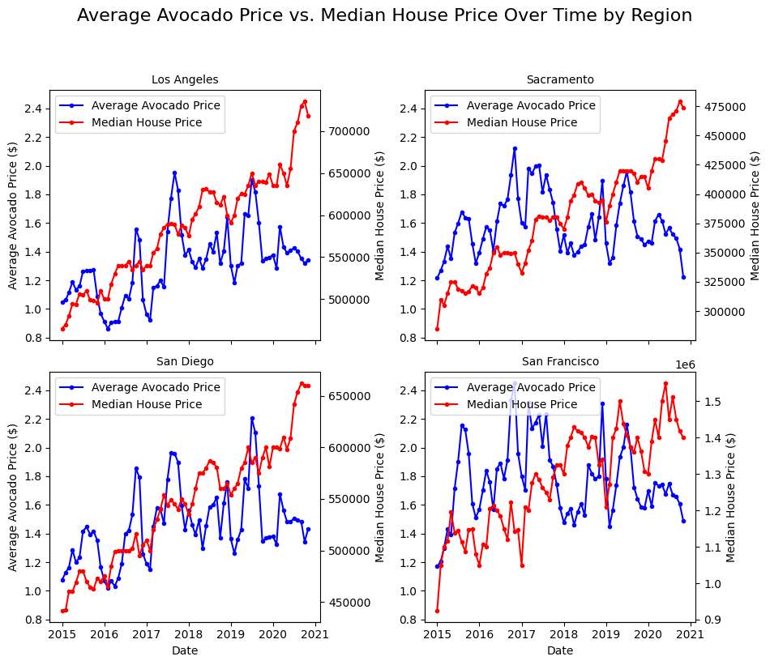

```python
import matplotlib.pyplot as plt
import seaborn as sns

# Group by date and geography and calculate the mean average_price and median house price
# We group because there might be multiple entries per date/geography in the avocado data
df_trend = df_joined.groupby(['date', 'geography']).agg(
    avg_avocado_price=('average_price', 'mean'),
    median_house_price=('Median Sale Price', 'mean') # Use mean here since Median Sale Price is already a median
).reset_index()

# Create a color palette for the different regions
palette = sns.color_palette("tab10", len(df_trend['geography'].unique()))
color_map = {region: color for region, color in zip(df_trend['geography'].unique(), palette)}

# Create subplots for each California region
g = sns.FacetGrid(df_trend, col="geography", col_wrap=2, height=4, aspect=1.2, palette=color_map)

# Plot average avocado price as a line
g = g.map(plt.plot, "date", "avg_avocado_price", marker='.', linestyle='-', label='Average Avocado Price', color='blue')

# Create a secondary y-axis for median house price
def plot_house_price(x, y, color, **kwargs):
    ax = plt.gca()
    ax2 = ax.twinx()
    ax2.plot(x, y, marker='.', linestyle='-', color='red', label='Median House Price')
    ax2.set_ylabel('Median House Price ($)')
    # Add legend to the second axis
    lines, labels = ax.get_legend_handles_labels()
    lines2, labels2 = ax2.get_legend_handles_labels()
    ax2.legend(lines + lines2, labels + labels2, loc='upper left')


# Plot median house price on the secondary y-axis
g = g.map(plot_house_price, "date", "median_house_price", color='red')

# Set titles and labels
g.fig.suptitle('Average Avocado Price vs. Median House Price Over Time by Region', y=1.02, fontsize=16)
g.set_titles("{col_name}")
g.set_xlabels("Date")
g.set_ylabels("Average Avocado Price ($)")


plt.tight_layout(rect=[0, 0, 1, 0.98]) # Adjust layout to prevent title overlap
plt.show()
```

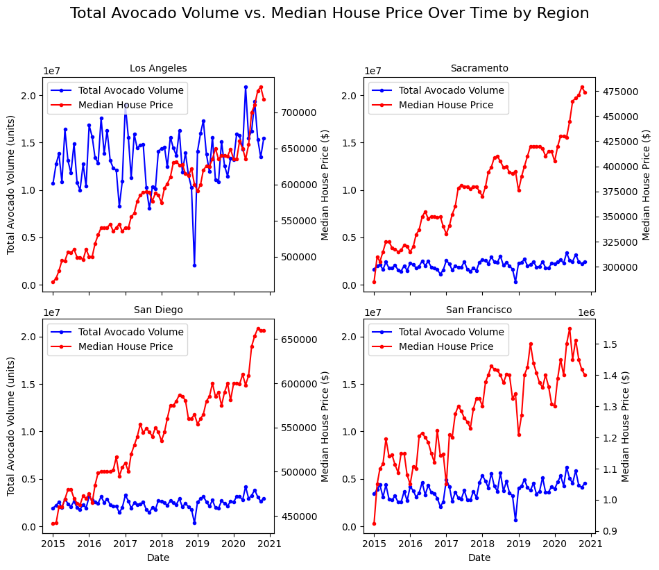

```python
import matplotlib.pyplot as plt
import seaborn as sns

# Group by date and geography and calculate the sum of total_volume and median house price
# We group because there might be multiple entries per date/geography in the avocado data
df_trend = df_joined.groupby(['date', 'geography']).agg(
    total_avocado_volume=('total_volume', 'sum'), # Calculate sum of total_volume
    median_house_price=('Median Sale Price', 'mean') # Use mean here since Median Sale Price is already a median
).reset_index()

# Create a color palette for the different regions
palette = sns.color_palette("tab10", len(df_trend['geography'].unique()))
color_map = {region: color for region, color in zip(df_trend['geography'].unique(), palette)}

# Create subplots for each California region
g = sns.FacetGrid(df_trend, col="geography", col_wrap=2, height=4, aspect=1.2, palette=color_map)

# Plot total avocado volume as a line
g = g.map(plt.plot, "date", "total_avocado_volume", marker='.', linestyle='-', label='Total Avocado Volume', color='blue')

# Create a secondary y-axis for median house price
def plot_house_price(x, y, color, **kwargs):
    ax = plt.gca()
    ax2 = ax.twinx()
    ax2.plot(x, y, marker='.', linestyle='-', color='red', label='Median House Price')
    ax2.set_ylabel('Median House Price ($)')
    # Add legend to the second axis
    lines, labels = ax.get_legend_handles_labels()
    lines2, labels2 = ax2.get_legend_handles_labels()
    ax2.legend(lines + lines2, labels + labels2, loc='upper left')


# Plot median house price on the secondary y-axis
g = g.map(plot_house_price, "date", "median_house_price", color='red')

# Set titles and labels
g.fig.suptitle('Total Avocado Volume vs. Median House Price Over Time by Region', y=1.02, fontsize=16)
g.set_titles("{col_name}")
g.set_xlabels("Date")
g.set_ylabels("Total Avocado Volume (units)")


plt.tight_layout(rect=[0, 0, 1, 0.98]) # Adjust layout to prevent title overlap
plt.show()
```

When comparing both the average avacado price and total avacado volume (measured in 1e7 as seen at the top of the graph) against median house rice in the four major california cities, we clearly see there is no meaningful relationship between avacado conssumption and house affordability

Avacdo prices fluctuate depending on season and year, and although there has been slight growth, it is NOTHING compared to the huge increase in house prices. Additionally, not only is their price that much more over 2015-2021, but not that many more are being bought, as seen by the second set of graphs. Both show us that prices are not up that dramatically from 2015 to 2021, nor are the amount being purchased, but what is up signifcantly is the median house price.

To conclude this, Millennials aren’t priced out of home ownership because of avacdo toast. The media might see these spending habits, but by looking at avacod purchase hisotry form 2015 - 2021 and comparing it to median house price, we see there is clearly something completely different at play here, something that is out of the mellianial’s occasional trendy avacodo’s hands. There is much larger economic and plotical factors impacting this, beyond the myth that Millennials can’t afford houses, because they spend all their money buying avocado toast